# Fechas y horas

## 0.1 Introducción

Trabajar con fechas y horas parece más fácil de lo que es en realidad ya que hay que lidiar con dos fenómenos:

- Físicos: rotación de la tierra y su órbita alrededor del sol
- Geopolíticos: meses, usos horarios, horarios de verano.

El capítulo presenta el paquete `lubridate`el cual no es parte de los paquetes de `tidyverse`ya que se considera un tema específico:

```r
library(tidyverse)
library(lubridate)
library(datos)
```

## 0.2 Creando fechas y horas

Hay tres tipos de datos de fecha que se refieren a instantes del tiempo diferentes:

- Una fecha o **date**. Un tibble lo imprime como `<date>`.
- Una hora o **time** dentro de un día. Los tibbles lo imprimen como `<time>`.
- Una fecha-hora o **date-time** es una fecha con una hora adjunta: Los tibbles imprimen esto como `<dttm>`. En otras partes de R se les llama POSIXct, pero no es un nombre muy útil.

En el capítulo se trata sólo con fechas y fechas-hora ya que R no tiene una clase nativa para almacenar horas, se recomienda para esto el paquete **hms**.

```r
today()
```

```
## [1] "2020-04-27"
```

```r
now()
```

```
## [1] "2020-04-27 18:28:57 -04"
```

Se recomienda también siempre usar el tipo más sencillo de datos (fecha) según lo que tus datos requieran, ya que date-time implica trabajar con usos horarios.

Hay tres modos en los que se puede crear una fecha/hora

### 0.2.1 Desde una cadena de caracteres

Se utilizan las funciones con los componentes `y, m, d` del paquete **lubridate**

Para fechas:

```r
ymd("2000-02-28")
```

```
## [1] "2000-02-28"
```

```r
mdy("02-28-2000")
```

```
## [1] "2000-02-28"
```

Para fecha-hora:

```r
# fecha con hora:miniuto:segundo
ymd_hms("2017-01-31 20:11:59")
```

```
## [1] "2017-01-31 20:11:59 UTC"
```

```r
# fecha con hora:minuto
mdy_hm("01/31/2017 08:01")
```

```
## [1] "2017-01-31 08:01:00 UTC"
```

```r
# fecha con uso horario
ymd(20170131, tz = "UTC")
```

```
## [1] "2017-01-31 UTC"
```

### 0.2.2 Desde componentes de fecha-hora individuales.

```r
vuelos %>%
  select(anio, mes, dia, hora, minuto)
```

```
## # A tibble: 336,776 x 5
##     anio   mes   dia  hora minuto
##    <int> <int> <int> <dbl>  <dbl>
##  1  2013     1     1     5     15
##  2  2013     1     1     5     29
##  3  2013     1     1     5     40
##  4  2013     1     1     5     45
##  5  2013     1     1     6      0
##  6  2013     1     1     5     58
##  7  2013     1     1     6      0
##  8  2013     1     1     6      0
##  9  2013     1     1     6      0
## 10  2013     1     1     6      0
## # ... with 336,766 more rows
```

Se utilizan las funciones `make_date()` y `make_datetime()`

```r
vuelos %>%
  select(anio, mes, dia, hora, minuto, salida_programada) %>%
  mutate(salida = make_datetime(year = anio, month = mes, day = dia, hour = hora, min = minuto),
         sp = make_datetime(anio, mes, dia, salida_programada %/% 100, salida_programada %% 100))
```

```
## # A tibble: 336,776 x 8
##     anio   mes   dia  hora minuto salida_programa~ salida
##    <int> <int> <int> <dbl>  <dbl>            <int> <dttm>
##  1  2013     1     1     5     15              515 2013-01-01 05:15:00
##  2  2013     1     1     5     29              529 2013-01-01 05:29:00
##  3  2013     1     1     5     40              540 2013-01-01 05:40:00
##  4  2013     1     1     5     45              545 2013-01-01 05:45:00
##  5  2013     1     1     6      0              600 2013-01-01 06:00:00
##  6  2013     1     1     5     58              558 2013-01-01 05:58:00
##  7  2013     1     1     6      0              600 2013-01-01 06:00:00
##  8  2013     1     1     6      0              600 2013-01-01 06:00:00
##  9  2013     1     1     6      0              600 2013-01-01 06:00:00
## 10  2013     1     1     6      0              600 2013-01-01 06:00:00
## # ... with 336,766 more rows, and 1 more variable: sp <dttm>
```

```r
hacer_fechahora_100 <- function(anio, mes, dia, tiempo){
  make_datetime(anio, mes, dia, tiempo %/% 100, tiempo %% 100)
}


vuelos_dt <- vuelos %>%
  filter(!is.na(horario_salida), !is.na(horario_llegada)) %>%
  mutate(
    horario_salida = hacer_fechahora_100(anio, mes, dia, horario_salida),
    horario_llegada = hacer_fechahora_100(anio, mes, dia, horario_llegada),
    salida_programada = hacer_fechahora_100(anio, mes, dia, salida_programada),
    llegada_programada = hacer_fechahora_100(anio, mes, dia, llegada_programada)
  ) %>%
  select(origen, destino, starts_with("atraso"), starts_with("horario"), ends_with("programada"), tiempo_vuelo)
```

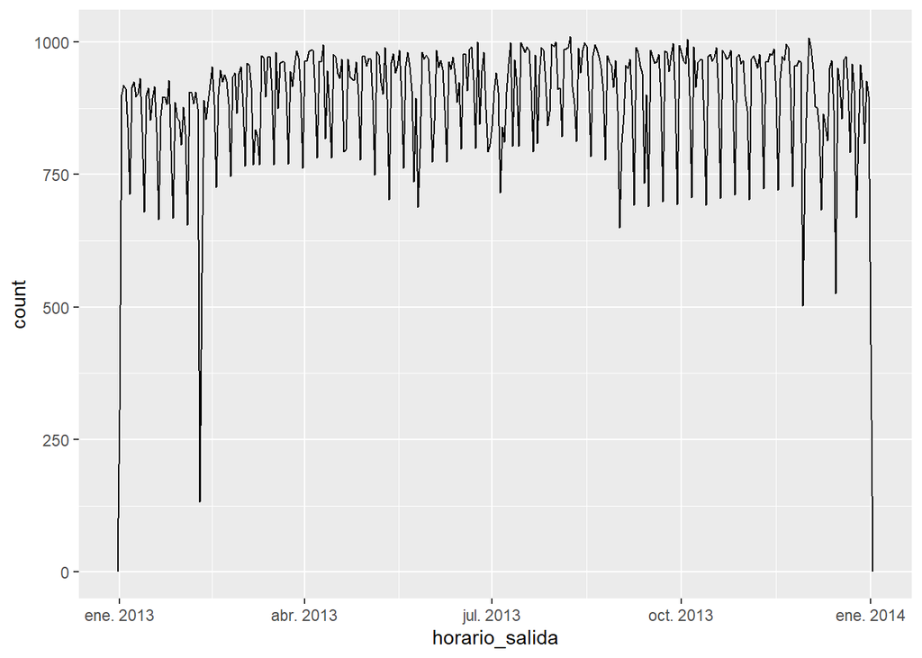

```r
vuelos_dt %>%
  ggplot(aes(horario_salida)) +
  geom_freqpoly(binwidth = 86400) # 86400 segundos = 1 día
```

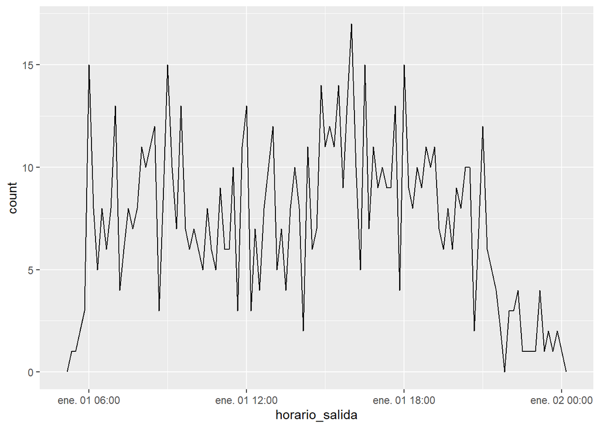

```r
vuelos_dt %>%
  filter(horario_salida < ymd(20130102)) %>%
  ggplot(aes(horario_salida)) +
  geom_freqpoly(binwidth = 600) # 600 segundos = 10 minutos
```

### 0.2.3 Desde un objeto fecha-hora existente

Usando `as_date()` o `as_datetime()`

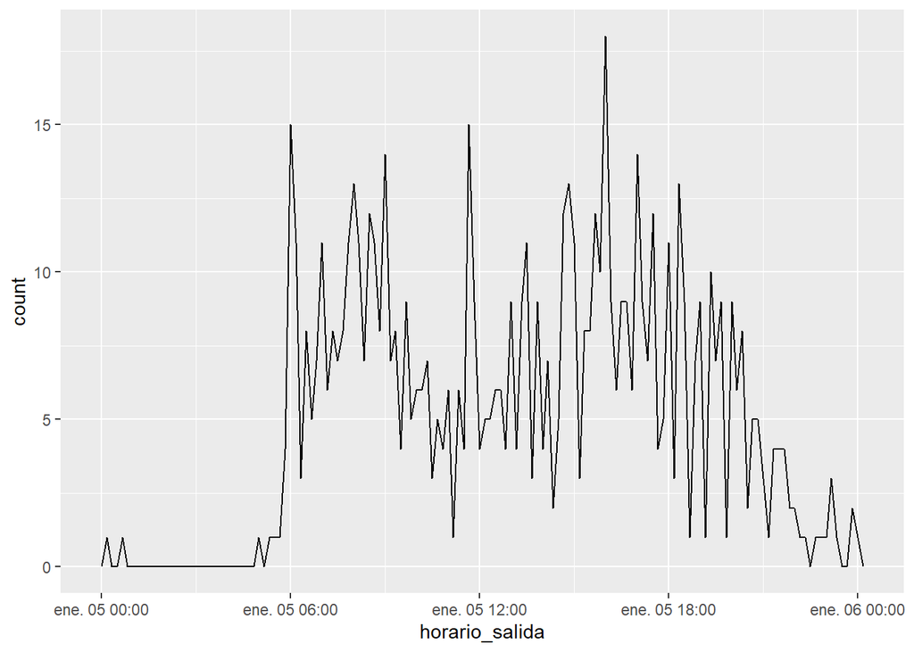

```r
vuelos_dt %>%
  filter(as_date(horario_salida) == ymd(20130105)) %>%
  ggplot(aes(horario_salida)) +
  geom_freqpoly(binwidth = 600) # 600 segundos = 10 minutos
```

Ejercicios

```r
d1 <- "Enero 1, 2010"
mdy(d1)
```

```
## [1] "2010-01-01"
```

```r
d2 <- "2015-Mar-07"
ymd(d2)
```

```
## [1] NA
```

```r
d3 <- "06-Jun-2017"
dmy(d3)
```

```
## [1] "2017-06-06"
```

```r
d4 <- c("Agosto 19 (2015)", "Julio 1 (2015)")
mdy(d4)
```

```
## [1] "2015-08-19" "2015-07-01"
```

```r
d5 <- "12/30/14" # Diciembre 30, 2014
mdy(d5)
```

```
## [1] "2014-12-30"
```

## 0.3 Componentes de fecha-hora

Se puede acceder a los componentes de una fecha-hora con las siguientes funciones: - year() (año) - month() (mes) - mday() (día del mes) - yday() (día del año) - wday() (día de la semana) - hour() (hora) - minute() (minuto) - second() (segundo)

```r
fechahora <- ymd_hms("2020-04-27 18:24:34")
year(fechahora)
```

```
## [1] 2020
```

```r
month(fechahora)
```

```
## [1] 4
```

```r
day(fechahora)
```

```
## [1] 27
```

```r
hour(fechahora)
```

```
## [1] 18
```

```r
minute(fechahora)
```

```
## [1] 24
```

```r
second(fechahora)
```

```
## [1] 34
```

```r
yday(fechahora)
```

```
## [1] 118
```

```r
wday(fechahora, label = T)
```

```
## [1] lun
## Levels: dom < lun < mar < mié < jue < vie < sáb
```

Podemos usar `wday()` para ver que son más los vuelos que salen durante la semana que durante el fin de semana:

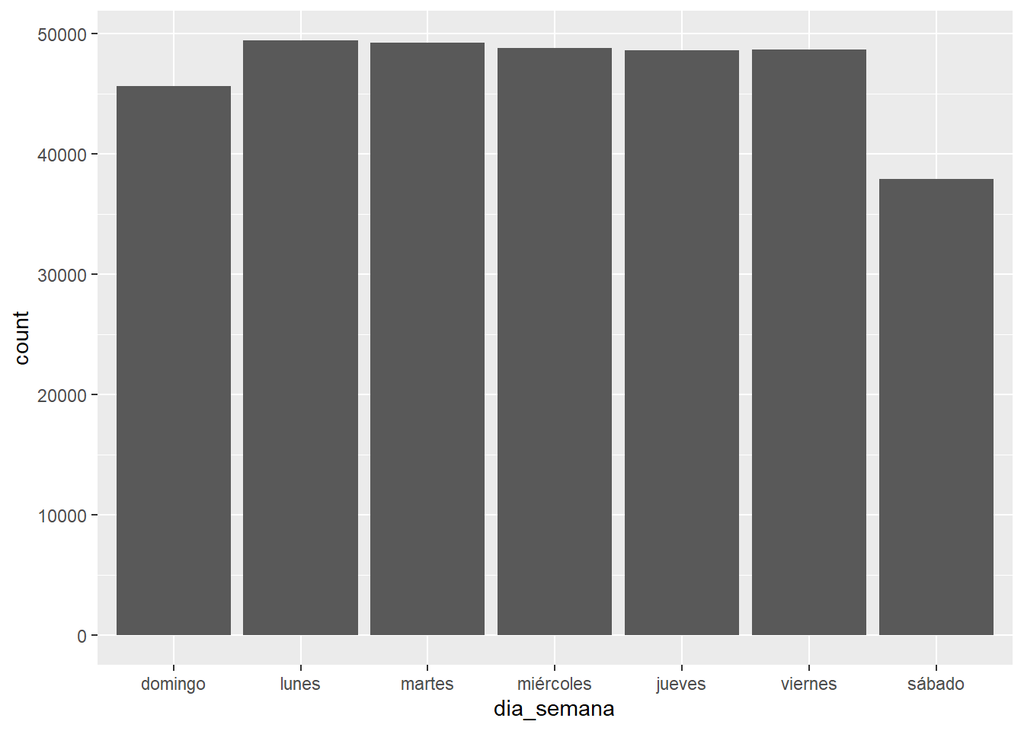

```r
vuelos_dt %>%
  mutate(dia_semana = wday(horario_salida, label = TRUE, abbr = F)) %>%
  ggplot(aes(x = dia_semana)) +
  geom_bar()
```

Uso con la función summarise:

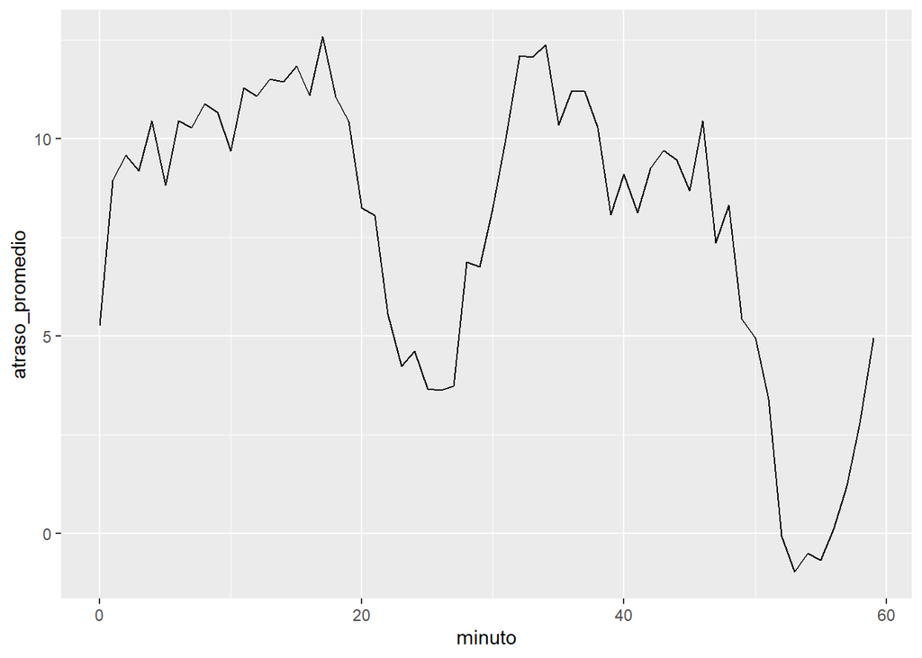

```r
vuelos_dt %>%
  mutate(minuto = minute(horario_salida)) %>%
  group_by(minuto) %>%
  summarise(
    atraso_promedio = mean(atraso_llegada, na.rm = TRUE),
    n = n()
  ) %>%
  ggplot(aes(minuto, atraso_promedio)) +
  geom_line()
```

Redondeo de fechas:

```r
fechahora2 <- ymd_hms("2020-04-27 22:46:47")
floor_date(fechahora2, unit = "hour")
```

```
## [1] "2020-04-27 22:00:00 UTC"
```

```r
round_date(fechahora2, unit = "hour")
```

```
## [1] "2020-04-27 23:00:00 UTC"
```

```r
ceiling_date(fechahora2, unit = "hour")
```

```
## [1] "2020-04-27 23:00:00 UTC"
```

## 0.4 Lapsos de tiempo

¿Cómo funciona la aritmética con las fechas?

Hay que tener claro lo siguiente:

- **durations** (duraciones), representa un número exacto de segundos
- **periods** (períodos), representan unidades humanas como semanas o meses
- **intervals** (intervalos),representan un punto de inicio y uno de finalización

### 0.4.1 Duraciones

Cuando se restan dos fechas, se obtiene un objeto de tipo `difftime`

```r
## ¿Qué edad tengo?

edad <- today() - dmy(01121990)
edad
```

```
## Time difference of 10740 days
```

```r
as.duration(edad)
```

```
## [1] "927936000s (~29.4 years)"
```

Se pueden construir duraciones con las funciones **d** (notar también el plural):

```r
dseconds(15)
```

```
## [1] "15s"
```

```r
dminutes(10)
```

```
## [1] "600s (~10 minutes)"
```

```r
dhours(c(12, 24))
```

```
## [1] "43200s (~12 hours)" "86400s (~1 days)"
```

```r
ddays(0:5)
```

```
## [1] "0s"                "86400s (~1 days)"  "172800s (~2 days)"
## [4] "259200s (~3 days)" "345600s (~4 days)" "432000s (~5 days)"
```

```r
dweeks(3)
```

```
## [1] "1814400s (~3 weeks)"
```

```r
dyears(1)
```

```
## [1] "31557600s (~1 years)"
```

```r
today() - dyears(1)
```

```
## [1] "2019-04-27 18:00:00 UTC"
```

```r
now() + dhours(12)*3
```

```
## [1] "2020-04-29 06:29:02 -04"
```

¿Y qué ocurre con los cambios de horario?

```r
# Cambios de hora
cambio <- ymd_hms("2020-04-04 02:00:00", tz = "Chile/Continental")
cambio
```

```
## [1] "2020-04-04 02:00:00 -03"
```

```r
cambio + ddays(1)
```

```
## [1] "2020-04-05 01:00:00 -04"
```

### 0.4.2 Periodos

**lubridate** provee plazos de tiempo “humanos” los cuales no tienen duración en segundos. Al igual que las duraciones, se crean mediante las siguientes funciones (sin la **d**):

```r
seconds(15)
```

```
## [1] "15S"
```

```r
minutes(10)
```

```
## [1] "10M 0S"
```

```r
hours(c(12, 24))
```

```
## [1] "12H 0M 0S" "24H 0M 0S"
```

```r
days(7)
```

```
## [1] "7d 0H 0M 0S"
```

```r
months(1:6)
```

```
## [1] "1m 0d 0H 0M 0S" "2m 0d 0H 0M 0S" "3m 0d 0H 0M 0S" "4m 0d 0H 0M 0S"
## [5] "5m 0d 0H 0M 0S" "6m 0d 0H 0M 0S"
```

```r
weeks(3)
```

```
## [1] "21d 0H 0M 0S"
```

```r
years(1)
```

```
## [1] "1y 0m 0d 0H 0M 0S"
```

También se puede hacer aritmética con los periodos:

```r
today() + months(3)
```

```
## [1] "2020-07-27"
```

```r
months(6) + years(5)
```

```
## [1] "5y 6m 0d 0H 0M 0S"
```

```r
(months(3)*4) + years(2)
```

```
## [1] "2y 12m 0d 0H 0M 0S"
```

```r
cambio + days(1)
```

```
## [1] "2020-04-05 02:00:00 -04"
```

### 0.4.3 Intervalos

Los intervalos aceptan el cálculo con clases del mismo tipo: periodos v/s periodos y duraciones v/s duraciones:

Los intervalos se contabilizan en segundos, por lo que a veces no se obtiene lo que deseamos:

```r
years(1) / days(1)
```

```
## [1] 365.25
```

```r
years(1) %/% days(1)
```

```
## [1] 365
```

```r
ddays(14) / ddays(7)
```

```
## [1] 2
```

```r
years(1) / ddays(365)
```

```
## Error: Incompatible classes: <Period> / <Duration>
```

Existe una clase específica en **lubridate** para los intervalos, las clase ‘interval’, la cual puede hacerse mediante la función `interval()` o con el comando `%--%`.

### 0.4.4 Ejercicios

** Crea un vector de fechas dando el primer día de cada mes de 2015. Crea un vector de fechas dando el primer día de cada mes del año actual.**

```r
ymd("2015-01-01") + months(0:11)
```

```
##  [1] "2015-01-01" "2015-02-01" "2015-03-01" "2015-04-01" "2015-05-01"
##  [6] "2015-06-01" "2015-07-01" "2015-08-01" "2015-09-01" "2015-10-01"
## [11] "2015-11-01" "2015-12-01"
```

```r
ymd("2020-01-01") + months(0:11)
```

```
##  [1] "2020-01-01" "2020-02-01" "2020-03-01" "2020-04-01" "2020-05-01"
##  [6] "2020-06-01" "2020-07-01" "2020-08-01" "2020-09-01" "2020-10-01"
## [11] "2020-11-01" "2020-12-01"
```

```r
## Hacerlo más "programado"?
```

** Crea una función en la que, dado tu cumpleaños (como una fecha), retorne qué edad tienes en años.**

** ¿Por qué no funciona (today() %–% (today() + years(1)) / months(1) ?** - Porque falta un paréntisis -_-

## 0.5 Usos horarios

Para lidiar con los usos horarios debemos ser conscientes, en primer lugar, de si nuestros datos requieren un tratamiento especial, porque de lo contrario, estaríamos haciendo más trabajo del debido.

Los usos horarios están generalmente expresados según el continente/ciudad de ubicación, y existe una extensa lista de ellos que se puede consultar con la función `OlsonNames()` del paquete base.

**lubridate** siempre utiliza UTC (Tiempo Universal Coordinado) a no ser que se haya especificado otra cosa.

El uso horario es un elemento que sólo afecta a la impresión:

```r
(x1 <- ymd_hms("2015-06-01 12:00:00", tz = "America/New_York"))
```

```
## [1] "2015-06-01 12:00:00 EDT"
```

```r
(x2 <- ymd_hms("2015-06-01 18:00:00", tz = "Europe/Copenhagen"))
```

```
## [1] "2015-06-01 18:00:00 CEST"
```

```r
(x3 <- ymd_hms("2015-06-02 04:00:00", tz = "Pacific/Auckland"))
```

```
## [1] "2015-06-02 04:00:00 NZST"
```

```r
x1 - x2
```

```
## Time difference of 0 secs
```

```r
x2 - x3
```

```
## Time difference of 0 secs
```

```r
x1 - x3
```

```
## Time difference of 0 secs
```

Para cambiar los husos horarios

```r
## Para cargar el uso horario "de impresión"
x4 <- c(x1, x2, x3)

with_tz(x4, tzone = "UTC")
```

```
## [1] "2015-06-01 16:00:00 UTC" "2015-06-01 16:00:00 UTC"
## [3] "2015-06-01 16:00:00 UTC"
```

```r
## Cuando se han etiquetado con un uso horario incorrecto:
force_tz(x4, tzone = "Australia/Lord_Howe")
```

```
## [1] "2015-06-01 12:00:00 +1030" "2015-06-01 12:00:00 +1030"
## [3] "2015-06-01 12:00:00 +1030"
```